# test_AL_jupiter.py

### Active Learning experimental

The leading idea behind Active Learning (AL) is that a classifier trained on a small set of well-chosen samples can perform as well as a classifier trained on a larger number of randomly chosen samples, while the first requires fewer human resources for training data gathering.

Active learning focuses on the interaction between the user and the classifier. In other words, the model returns to the user the areas where classification outcome is the most uncertain. After accurate labeling by the user, samples from those areas are included into the training set in order to reinforce the model.

```python
import os
import time

import numpy as np
import pandas as pd
import pandas_profiling
from statistics import mean, stdev
from collections import Counter
import pickle
import itertools
from sklearn.preprocessing import StandardScaler
from sklearn.datasets import fetch_openml
import seaborn as sns
import matplotlib.pyplot as plt

from sklearn.linear_model import LogisticRegression
from sklearn.ensemble import RandomForestClassifier
from sklearn.ensemble import GradientBoostingClassifier
from sklearn.svm import SVC

from sklearn.model_selection import train_test_split
from sklearn.metrics import classification_report
```

## Import datasets

#### Indian Pines dataset

```python
def download():
    # Doanload Indian Pines dataset from OpenML platform
    X, y = tuple(fetch_openml('Indian_pines').values())[:2]

    # Unmute the line to binerize the data
    #y = np.array((y== 'Soybeans').astype(int))

    class_size = Counter(y)
    print ('Indianpines dataset:', '\nN samples:',X.shape[0],'\nN features:',X.shape[1],'\n')
    print (f'Classes size:\n{pd.Series(dict(Counter(y).most_common()))}')
    dataset =  np.column_stack((y, X.astype(np.object)))
    return (X, y)
```

### Descriptive analysis

Let's see how does the dataset look like

```python
X,y = download()
# Print dataset as a table
pd.DataFrame(np.column_stack((y, X.astype(np.object)))).head(5)
```

```
Indianpines dataset:
N samples: 9144
N features: 220

Classes size:
Soybeans    4050
Corn        2502
Trees       1294
Grass        523
Hay          489
Wheat        212
Alfalfa       54
Oats          20
dtype: int64
```

|  | 0 | 1 | 2 | 3 | 4 | 5 | 6 | 7 | 8 | 9 | ... | 211 | 212 | 213 | 214 | 215 | 216 | 217 | 218 | 219 | 220 |
| --- | --- | --- | --- | --- | --- | --- | --- | --- | --- | --- | --- | --- | --- | --- | --- | --- | --- | --- | --- | --- | --- |
| 0 | Alfalfa | 3373 | 4124 | 4229 | 4197 | 4476 | 4824 | 4789 | 4701 | 4687 | ... | 1058 | 1064 | 1060 | 1054 | 1043 | 1044 | 1022 | 1023 | 1009 | 1000 |
| 1 | Alfalfa | 3028 | 3994 | 4218 | 4192 | 4423 | 4564 | 4708 | 4572 | 4563 | ... | 1066 | 1058 | 1057 | 1041 | 1035 | 1029 | 1022 | 1018 | 996 | 1004 |
| 2 | Alfalfa | 3202 | 4118 | 4315 | 4330 | 4723 | 4877 | 5105 | 4909 | 4909 | ... | 1084 | 1086 | 1093 | 1067 | 1050 | 1050 | 1034 | 1019 | 1000 | 1004 |
| 3 | Alfalfa | 3375 | 3995 | 4302 | 4112 | 4519 | 4808 | 4859 | 4763 | 4761 | ... | 1068 | 1064 | 1070 | 1051 | 1041 | 1035 | 1031 | 1029 | 1004 | 1000 |
| 4 | Alfalfa | 3541 | 4119 | 4213 | 4188 | 4467 | 4847 | 4897 | 4831 | 4761 | ... | 1066 | 1057 | 1072 | 1048 | 1046 | 1046 | 1039 | 1010 | 1000 | 1000 |

5 rows × 221 columns

As the scanner is a hyperspectral (HS), we asume a correlation in between the spectal channels

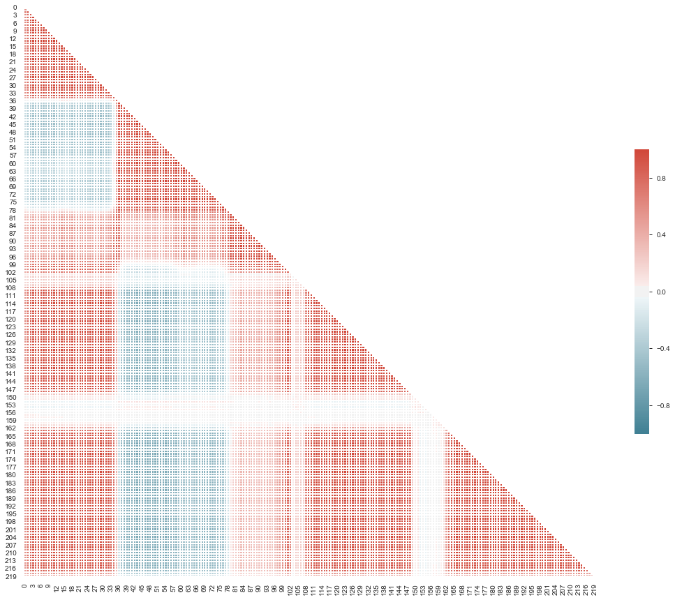

```python
def make_correlation_matrix(df, corr_type='pearson'):
    sns.set_style('white')
    # Compute the correlation matrix
    corr = df.corr(corr_type)
    # Generate a mask for the upper triangle
    mask = np.triu(np.ones_like(corr, dtype=np.bool))
    # Set up the matplotlib figure
    f, ax = plt.subplots(figsize=(20, 15))
    # Generate a custom diverging colormap
    cmap = sns.diverging_palette(220, 15, as_cmap=True)
    # Draw the heatmap with the mask and correct aspect ratio
    sns.heatmap(corr, mask=mask, cmap=cmap, vmax=1, vmin=-1, center=0,
                square=True, linewidths=.5, cbar_kws={"shrink": .5})  #annot=True

make_correlation_matrix(pd.DataFrame(X))
```

### Split dataset into train set, test set and unlabel pool

```python
def split(X,y, train_size, test_size):
    """ Split dataset into 3 partitions for Active Learning procedure"""

    x_train, x_pool, y_train, y_pool = train_test_split(X, y, train_size = train_size, stratify = y)

    unlabel, x_test, label, y_test = train_test_split( x_pool, y_pool, test_size = test_size, stratify = y_pool)

    # Feature scalling
    sc = StandardScaler()

    x_train = sc.fit_transform(x_train)
    x_test = sc.fit_transform(x_test)
    unlabel = sc.fit_transform(unlabel)

    return x_train, y_train, x_test, y_test, unlabel, label
```

### Data selection strategies - Entropy, Margin, Random

The key task in Active Learning is selection of a proper method for ranking the prediction’s uncertainty based on classifier’s probability output.

#### Entropy Sampling

Aftr each suervised classification, based on the sample's prediction probability, the entropy meeasure (or purity measure) is calculated and used as heuristic for high uncertainty sample selection.

#### Margin Sampling

Margin sampling is multi-class uncertainty sampling variant that considers the difference of the probability of two highest probable classes: he smaller is the difference, the higher is the labeling uncertainty for the given pixel.

```python
def EntropySelection(y_probab):
    ''' Uncertainty with Entropy value'''
    # Entropy measure
    # Avoid having absolut 0 for probab. values for RF classifier
    if model.__name__ =='RF':
        y_prob = np.where(np.isin(y_probab, [0,1]), np.clip(y_probab,1e-10,1), y_probab)
        e = (-y_prob * np.log2(y_prob)).sum(axis=1)
    else:
        e = (-y_probab * np.log2(y_probab)).sum(axis=1)
    selection = (np.argsort(e)[::-1])[:step]
    selection = list(selection)
    return selection

def MarginSamplingSelection(y_probab):
    ''' Uncertainty with Margine sampling '''
    # Selecting Margine samples
    rev = np.sort(y_probab, axis=1)[:, ::-1]
    # Subtracting the probability of 2 highest classes
    values = rev[:, 0] - rev[:, 1]
    selection = np.argsort(values)[:step]
    return selection

def RandomSelection(y_probab):
    '''Random Selection'''
    selection = np.random.choice(y_probab.shape[0], step, replace=False)
    #selection = list(selection)
    return selection
```

### Classification Models

```python
'''
Random Forest Classifier
'''
def RF(x_train, y_train, unlabel, x_test, y_test ):
    classifier = RandomForestClassifier(n_estimators=1000)
    classifier.fit(x_train, y_train)
    y_probab = classifier.predict_proba(unlabel)
    score = classifier.score(x_test, y_test)
    return (y_probab, score)

'''
Logistic Regression
'''
def LogReg(x_train, y_train, unlabel, x_test, y_test ):
    param = {
            'C': 50,
            'multi_class': 'multinomial',
            'penalty': 'l2',
            'solver': 'lbfgs',
            'max_iter': 1200,
            }
    classifier = LogisticRegression(**param)
    classifier.fit(x_train, y_train)
    y_probab = classifier.predict_proba(unlabel)
    score = classifier.score(x_test, y_test)
    return (y_probab, score)

'''
GradientBoostingClassifier
'''
def GBC(x_train, y_train, unlabel, x_test, y_test):
    param = {
            'n_estimators': 1200,
            'max_depth': 3,
            'subsample': 0.5,
            'learning_rate': 0.01,
            'min_samples_leaf': 1,
            'random_state': 3,
            }
    classifier = GradientBoostingClassifier(**param)
    classifier.fit(x_train,y_train)
    y_probab = classifier.predict_proba(unlabel)
    score = classifier.score(x_test, y_test)
    return (y_probab, score)

'''
Support Vector Machine
'''
def SVM(x_train, y_train, unlabel, x_test, y_test):
    param = {
            'kernel': 'rbf',
            'probability': True, # neccessary for AL process
            'gamma': 'auto'
            }
    classifier = SVC(**param)
    classifier.fit(x_train,y_train)
    y_probab = classifier.predict_proba(unlabel)
    score = classifier.score(x_test, y_test)
    return (y_probab, score)
```

### Save/Load pickled data

```python
def pickle_save(fname, data):
    filehandler = open(fname,"wb")
    pickle.dump(data,filehandler)
    filehandler.close()
    print('saved', fname, os.getcwd(), os.listdir())

def pickle_load(fname):
    file = open(fname,'rb')
    data = pickle.load(file)
    file.close()
    return data
```

## Experiment setup

```python
# Set up the parameters for the experiment
steps = [10, 20, 40] # number of samples to be labeled after each iteration
iters = 5 # number of iterations within each selection step
models = [RF, SVM, LogReg]#, GBC]
selection_functions = [MarginSamplingSelection, EntropySelection, RandomSelection]
```

### Active Learning experiment

```python
# Run Active learinig procedure for each combination of classifier and sample selection method 5 times
# Save results after each Step

for step in steps:

    # Store accuracies after each iteration
    acc = {}

    for model in models:
        #print(model.__name__)

        for selection_function in selection_functions:
            print(model.__name__+ '_' +selection_function.__name__ +'_'+ str(step))
            acc[model.__name__+ '_' +selection_function.__name__ +'_'+ str(step)] = {}

            for i in range(1,iters+1): # number of iterations
                #print('Iter: ', i)

                # Split dataset into train(5 %), test(25 %), unlabel(70 %)
                x_train, y_train, x_test, y_test, unlabel, label = split(X, y, 0.05, 0.25)

                # Let the active method select up to ~20% of training data
                max_training = round(0.2*len(label))

                # Create an empty list inside the dictionary for each iteration
                acc[model.__name__+ '_' +selection_function.__name__+'_'+ str(step)][f'iter_{i}'] = []

                # Create list to record the training data for each iteration
                acc[f'step_{step}'] = []

                '''Active Selection'''
                while len(x_train) <= max_training:
                    # Probability by a classifier
                    y_probab, _ = model(x_train, y_train, unlabel, x_test, y_test)
                    # Uncertainty points selected by a given selection strategy
                    uncrt_pt_ind = selection_function(y_probab)

                    # Print('x_train before Iter', x_train.shape[0])
                    x_train = np.append(unlabel[uncrt_pt_ind, :], x_train, axis = 0)
                    y_train = np.append(label[uncrt_pt_ind], y_train)
                    unlabel = np.delete(unlabel, uncrt_pt_ind, axis = 0)
                    label = np.delete(label, uncrt_pt_ind)

                    # Record the accuracy after every iteration
                    _, score = model(x_train, y_train, unlabel, x_test, y_test)

                    # Print('x_train after Iter', x_train.shape[0])

                    # Append the accuracy to dictionary
                    acc[model.__name__+ '_' +selection_function.__name__+'_'+ str(step)][f'iter_{i}'].append(score)

                    # Record the training data after each iteration
                    acc[f'step_{step}'].append(len(x_train))

    # Save pickled disctionary with results
    fname = 'AL_full_experiment_Indian_pine_' + str(step) + '.pkl'
    pickle_save(fname, acc)
```

```
RF_MarginSamplingSelection_10
RF_EntropySelection_10
RF_RandomSelection_10
SVM_MarginSamplingSelection_10
SVM_EntropySelection_10
SVM_RandomSelection_10
LogReg_MarginSamplingSelection_10
LogReg_EntropySelection_10
LogReg_RandomSelection_10
saved AL_full_experiment_Indian_pine_10.pkl C:\Users\arman\Desktop\ActiveLearning\Experiment ['.ipynb_checkpoints', '1AL_full_experiment_Indian_pine_10.pkl', '1AL_full_experiment_Indian_pine_20.pkl', '1AL_full_experiment_Indian_pine_40.pkl', 'Active_learn_experiment.py', 'AL_exhaustive_run_Indian_pi…
RF_MarginSamplingSelection_20
RF_EntropySelection_20
RF_RandomSelection_20
SVM_MarginSamplingSelection_20
SVM_EntropySelection_20
SVM_RandomSelection_20
LogReg_MarginSamplingSelection_20
LogReg_EntropySelection_20
LogReg_RandomSelection_20
saved AL_full_experiment_Indian_pine_20.pkl C:\Users\arman\Desktop\ActiveLearning\Experiment ['.ipynb_checkpoints', '1AL_full_experiment_Indian_pine_10.pkl', '1AL_full_experiment_Indian_pine_20.pkl', '1AL_full_experiment_Indian_pine_40.pkl', 'Active_learn_experiment.py', 'AL_exhaustive_run_Indian_pi…
RF_MarginSamplingSelection_40
RF_EntropySelection_40
RF_RandomSelection_40
SVM_MarginSamplingSelection_40
SVM_EntropySelection_40
SVM_RandomSelection_40
LogReg_MarginSamplingSelection_40
LogReg_EntropySelection_40
LogReg_RandomSelection_40
saved AL_full_experiment_Indian_pine_40.pkl C:\Users\arman\Desktop\ActiveLearning\Experiment ['.ipynb_checkpoints', '1AL_full_experiment_Indian_pine_10.pkl', '1AL_full_experiment_Indian_pine_20.pkl', '1AL_full_experiment_Indian_pine_40.pkl', 'Active_learn_experiment.py', 'AL_exhaustive_run_Indian_pi…
```

### Standard Classification

In order to establish the upper boundaries of accuracy for different classifiers, we perform classification using standard train-test-split (test_size = 0.33 ). The procedure is repeted 5 times with random initialization and the results are avaraged.

```python
# Define list of accuracies for each classifier
acc1, acc2, acc3, acc4 = [], [], [], []

for _ in range(5):
    # Split the data into train/test
    X_train, X_test, Y_train, Y_test = train_test_split(X, y, random_state=None,
                                                            test_size=0.33, shuffle=True)

    # Normalize the training data
    X_train = StandardScaler().fit_transform(X_train)
    X_test = StandardScaler().fit_transform(X_test)

    # Set up Random Forest classifier
    classifier1 = RandomForestClassifier(n_estimators=1000)
    classifier1.fit(X_train, Y_train)
    acc1.append(classifier1.score(X_test, Y_test))

    # Set up Logistic Regression classifier
    param2 = {
            'C': 50,
            'multi_class': 'multinomial',
            'penalty': 'l1',
            'solver': 'saga',
            'max_iter': 2500,
            }
    classifier2 = LogisticRegression(**param2)
    classifier2.fit(X_train, Y_train)
    acc2.append(classifier2.score(X_test, Y_test))

    # Set up Support Vector classifier
    param3 = {
            'C': 1,
            'kernel': 'linear',
            'gamma': 'auto'
            }
    classifier3 = SVC(**param3)
    classifier3.fit(X_train, Y_train)
    acc3.append(classifier3.score(X_test, Y_test))

    '''
    # Set up Gradient Boosting classifier
    param4 = {
            'n_estimators': 1200,
            'max_depth': 3,
            'subsample': 0.5,
            'learning_rate': 0.01,
            'min_samples_leaf': 1,
            'random_state': 3,
            }
    classifier4 = GradientBoostingClassifier(**param4)
    classifier4.fit(X_train, y_train)
    acc4.append(classifier4.score(X_test, y_test))
    '''
print("Accuracy by RF :", mean(acc1)*100, "stdev: ", stdev(acc1)*100)
print("Accuracy by LogReg :", mean(acc2)*100, "stdev: ", stdev(acc2)*100)
print("Accuracy by SVM :", mean(acc3)*100, "stdev: ", stdev(acc3)*100)
#print("Accuracy by GBC :", mean(ac4)*100, "stdev: ", stdev(ac4)*100)
```

```
Accuracy by RF : 90.56991385023194 stdev:  0.7120454716877074
Accuracy by LogReg : 90.62955599734924 stdev:  0.3266734935418486
Accuracy by SVM : 90.93439363817097 stdev:  0.21550182294909287
```

```python
# Steore the results in a dictionary
standard = {}
standard['standard_RF'] = mean(acc1).round(2)
standard['standard_LogReg'] = mean(acc2).round(2)
standard['standard_SVM'] = mean(acc3).round(2)

print(standard)
```

```
{'standard_RF': 0.91, 'standard_LogReg': 0.91, 'standard_SVM': 0.91}
```

### Visualize the results

Before vizualizing the results, let's calculate the average, the minimum and maximum accuracies in case we run the same combination more than once

```python
def calculate_stat(step, experiment_name):
    '''Calculate mean values for classification outputs for N iterations and
    add to the values of iterations in the dictionary'''

    # load accuracy results from the pickeld dictionary
    acc = pickle_load(experiment_name + str(step)+'.pkl')

    # Calculate mean, min and max accuracies if the iterations are more than 1
    if len(acc[(list(acc))[0]]) >1:

        for model in models_str:
            for selection_function in selection_functions_str:

                # Make a list of lists containing accuracies for each iteration
                to_list = [acc[f'{model}_{selection_function}_{step}'][keys] for keys in acc[f'{model}_{selection_function}_{step}']]

                # calculate mean accuracies from  n iterations for each step
                mean_acc = [mean(k) for k in zip(*to_list)]
                #stdev_acc = [stdev(k) for k in zip(*to_list)]

                # calculate min and max values for plotting
                min_acc = [min(k) for k in zip(*to_list)]
                max_acc = [max(k) for k in zip(*to_list)]

                # append calculated accuracies to the dictionary
                acc[f'{model}_{selection_function}_{step}']['mean'] = mean_acc
                #acc[f'{model}_{selection_function}_{step}']['stdev'] = stdev_acc

                acc[f'{model}_{selection_function}_{step}']['min'] = min_acc
                acc[f'{model}_{selection_function}_{step}']['max'] = max_acc
    else:
        pass
    return acc
```

Define function to plot Active Learning results

```python
def result_plot(step, model, selection_functions, acc):
    #sns.set_style('white')
    fig, ax = plt.subplots(figsize=(8, 6))

    if len(acc[(list(acc))[0]]) ==1:

        for selection in selection_functions_str:
            # Plot results for a single iteration
            ax.plot(acc[f'step_{step}'], acc[f'{model}_{selection}_{step}']['iter_1'], label = str(selection))
    else:
        for selection in selection_functions_str:

            # Plot the mean accuracies for a given model and selection strategy
            ax.plot(acc[f'step_{step}'], acc[f'{model}_{selection}_{step}']['mean'], label = str(selection))

            # Plot the min/max boundaries around the mean value
            plt.fill_between(acc[f'step_{step}'], acc[f'{model}_{selection}_{step}']['min'],
                            acc[f'{model}_{selection}_{step}']['max'], alpha = 0.3)

    # plot the upper results for the classifier with standard train/test split
    ax.axhline(standard[f'standard_{model}'], label=f'standard_{model}')

    ax.set_ylim([0.5,1])
    ax.grid(True)
    ax.legend(loc=4, fontsize='x-large')

    plt.xlabel('Training data', fontsize='x-large')
    plt.ylabel('Accuracy',  fontsize='x-large')
    plt.title(f'{model}     Step[{step}]',  fontsize='xx-large')
    plt.show()
```

```python
# Set up AL combinations for plotting
experiment_name = 'AL_full_experiment_Indian_pine_'
steps_str = ['10', '20', '40']
models_str = ['RF', 'LogReg', 'SVM']
selection_functions_str = ['MarginSamplingSelection', 'EntropySelection', 'RandomSelection']

# Calculate the statistics for N iterations
acc_10 = calculate_stat(10, experiment_name)
acc_20 = calculate_stat(20, experiment_name)
acc_40 = calculate_stat(40, experiment_name)

accuracies = [acc_10, acc_20, acc_40]

# Check if calculations are applied
acc_20['RF_MarginSamplingSelection_20'].keys()
```

```
dict_keys(['iter_1', 'iter_2', 'iter_3', 'iter_4', 'iter_5', 'mean', 'min', 'max'])
```

Let's vizualise the results and compare classifier and sample selection strategy performance against the standard train/test split scenatio

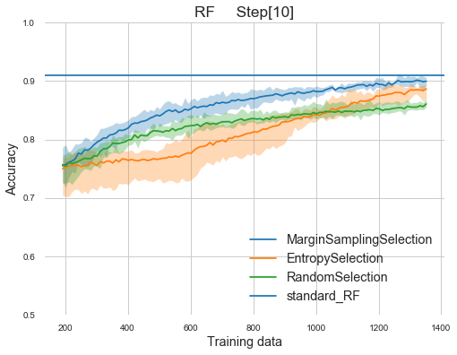

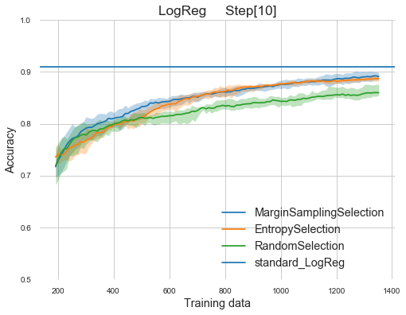

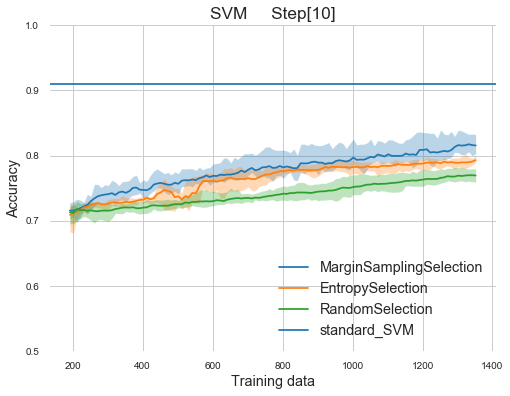

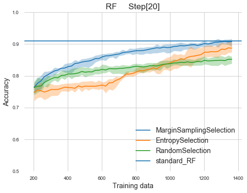

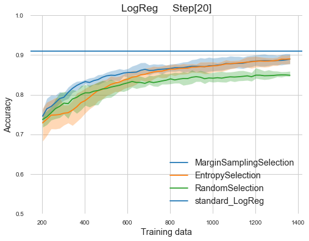

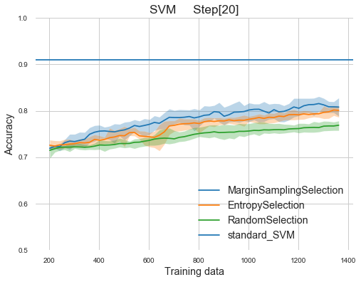

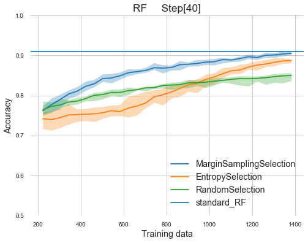

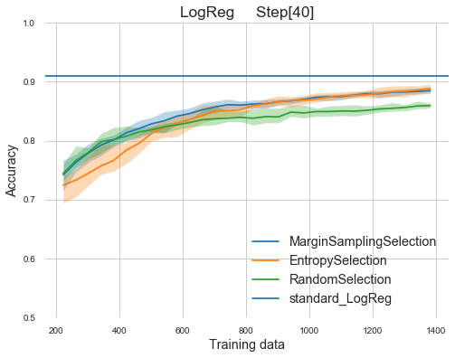

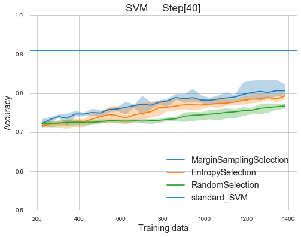

```python
# Plot the lines of average accuracies with min-max values
for step, acc in zip(steps_str, accuracies):
    for model in models_str:
        result_plot(step, model, selection_functions_str, acc)
```